# Online GREAT analysis

Repo: https://github.com/jokergoo/jokergoo.github.io/tree/master/talks

We first read the regions (peaks of the transcription factor JUN) as a data frame.

```r
bed = read.table("Encode3_JUN_hg19.bed")
head(bed)
```

```
##     V1      V2      V3 V4   V5 V6
## 1 chr1  936221  936347  . 1000  .
## 2 chr1 1280252 1280492  .  480  .
## 3 chr1 2143913 2144153  .  982  .
## 4 chr1 4052186 4052426  .  544  .
## 5 chr1 4440698 4440938  .  837  .
## 6 chr1 7359438 7359678  .  493  .
```

```r
dim(bed)
```

```
## [1] 1726    6
```

Use `submitGreatJob()` to submit the regions to the GREAT web server. By default the species is human (hg19). Current version of GREAT support `"hg38"`, `"hg19"`, `"mm10"`, `"mm9"`.

```r
library(rGREAT)
job = submitGreatJob(bed)
```

The summary of the job.

```r
job
```

```
## Submit time: 2023-08-03 10:06:20
##   Note the results may only be avaiable on GREAT server for 24 hours.
## Version: 4.0.4
## Species: hg19
## Inputs: 1726 regions
## Mode: Basal plus extension
##   Proximal: 5 kb upstream, 1 kb downstream,
##   plus Distal: up to 1000 kb
## Include curated regulatory domains
##
## Enrichment tables for following ontologies have been downloaded:
##   None
```

Next step is to select one or more ontology categories and to retrieve the result tables. There are many ontologies integrated in GREAT. The total ontologies can be get by:

```r
availableOntologies(job)
```

```
## [1] "GO Molecular Function"     "GO Biological Process"
## [3] "GO Cellular Component"     "Mouse Phenotype"
## [5] "Mouse Phenotype Single KO" "Human Phenotype"
## [7] "Ensembl Genes"
```

By default three GO ontologies are used.

```r
tbl = getEnrichmentTables(job)
```

```
## The default enrichment table does not contain informatin of associated
## genes for each input region. You can set `download_by = 'tsv'` to
## download the complete table, but note only the top 500 regions can be
## retreived. See the following link:
##
## https://great-help.atlassian.net/wiki/spaces/GREAT/pages/655401/Export#Export-GlobalExport
##
## Except the additional gene-region association column if taking 'tsv' as
## the source of result, all other columns are the same if you choose
## 'json' (the default) as the source. Or you can try the local GREAT
## analysis with the function `great()`.
```

Once the result tables are retrieved, they are cached.

```r
job
```

```
## Submit time: 2023-08-03 10:06:20
##   Note the results may only be avaiable on GREAT server for 24 hours.
## Version: 4.0.4
## Species: hg19
## Inputs: 1726 regions
## Mode: Basal plus extension
##   Proximal: 5 kb upstream, 1 kb downstream,
##   plus Distal: up to 1000 kb
## Include curated regulatory domains
##
## Enrichment tables for following ontologies have been downloaded:
##   GO Biological Process
##   GO Cellular Component
##   GO Molecular Function
```

More ontologies can be set via the `ontology` argument.

```r
getEnrichmentTable(job, ontology = c("GO Biological Process", "Mouse Phenotype"))
```

`tbl` is a list of three tables and each table contains enrichment results for a GO ontology:

```r
names(tbl)
```

```
## [1] "GO Molecular Function" "GO Biological Process" "GO Cellular Component"
```

```r
head(tbl[["GO Biological Process"]])
```

```
##           ID                                    name Binom_Genome_Fraction
## 1 GO:0009987                        cellular process             0.8819650
## 2 GO:0006950                      response to stress             0.2518874
## 3 GO:0042981         regulation of apoptotic process             0.1425860
## 4 GO:0010941                regulation of cell death             0.1563783
## 5 GO:0043067     regulation of programmed cell death             0.1441386
## 6 GO:0048523 negative regulation of cellular process             0.4096118
##   Binom_Expected Binom_Observed_Region_Hits Binom_Fold_Enrichment
## 1      1522.2720                       1647              1.081936
## 2       434.7576                        625              1.437583
## 3       246.1035                        403              1.637522
## 4       269.9089                        430              1.593130
## 5       248.7833                        403              1.619884
## 6       706.9899                        909              1.285733
##   Binom_Region_Set_Coverage Binom_Raw_PValue Binom_Adjp_BH Hyper_Total_Genes
```

[output cut: 27 more lines]

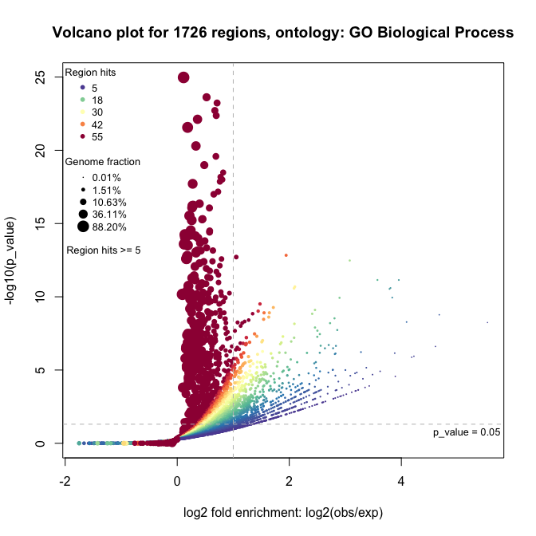

```r
plotVolcano(job, ontology = "GO Biological Process")
```

The global region-gene association plots:

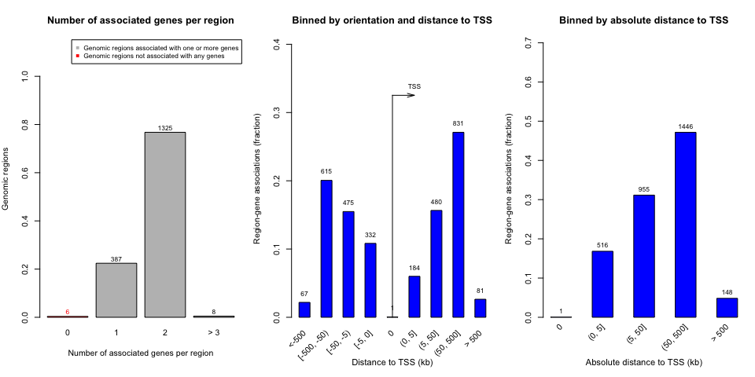

```r
plotRegionGeneAssociationGraphs(job)
```

Or the association specifically for a specific term.

```
## The webpage for 'GO Molecular Function:GO:0004984' is available at:
##   http://great.stanford.edu/public-4.0.4/cgi-bin/showTermDetails.php?termId=GO:0004984&ontoName=GOMolecularFunction&ontoUiName=GO Molecular Function&sessionName=20230803-public-4.0.4-ETOSE4&species=hg19&foreName=filed6f372f354b0.gz&backName=&table=region
##  Note the web page might be deleted from GREAT web server because it is only for temporary use.
```

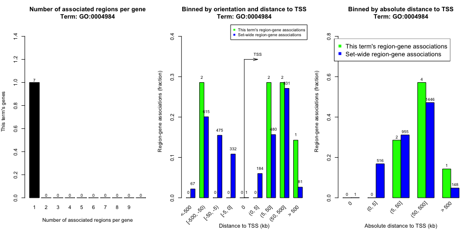

```r
plotRegionGeneAssociations(job, ontology = "GO Molecular Function",
    term_id = "GO:0004984")
```

The table of the associations between genes and regions.

```r
getRegionGeneAssociations(job, ontology = "GO Molecular Function",
    term_id = "GO:0004984")
```

```
## The webpage for 'GO Molecular Function:GO:0004984' is available at:
##   http://great.stanford.edu/public-4.0.4/cgi-bin/showTermDetails.php?termId=GO:0004984&ontoName=GOMolecularFunction&ontoUiName=GO Molecular Function&sessionName=20230803-public-4.0.4-ETOSE4&species=hg19&foreName=filed6f372f354b0.gz&backName=&table=region
##  Note the web page might be deleted from GREAT web server because it is only for temporary use.
```

```
## GRanges object with 6 ranges and 2 metadata columns:
##       seqnames              ranges strand | annotated_genes    dist_to_TSS
##          <Rle>           <IRanges>  <Rle> | <CharacterList>  <IntegerList>
##   [1]     chr9 125164745-125164985      * |           OR1J1          75370
##   [2]    chr11     5301878-5302118      * |          OR51B4          21228
##   [3]    chr11   56700437-56700677      * |    OR9G4,OR5AK2 -189270,-55790
##   [4]    chr14   22802493-22802733      * |           OR4E2         669316
##   [5]    chr15   22410075-22410315      * |           OR4N4          27813
##   [6]    chr17     2795933-2796173      * |           OR1D5         170848
##   -------
##   seqinfo: 5 sequences from an unspecified genome; no seqlengths
```

Note, you cannot get the association bewteen genes and *all* regions. It is not supported by the web GREAT.

There is a Shiny app that contains all the results.

```r
shinyReport(job)
```

Bonus: If you use the GO category, you can use the **simplifyEnrichment** to summarize the results.

```r
library(simplifyEnrichment)
tb = tbl[["GO Biological Process"]]
sig_go = tb$ID[tb$Binom_Adjp_BH < 0.01]
length(sig_go)
```

```
## [1] 853
```

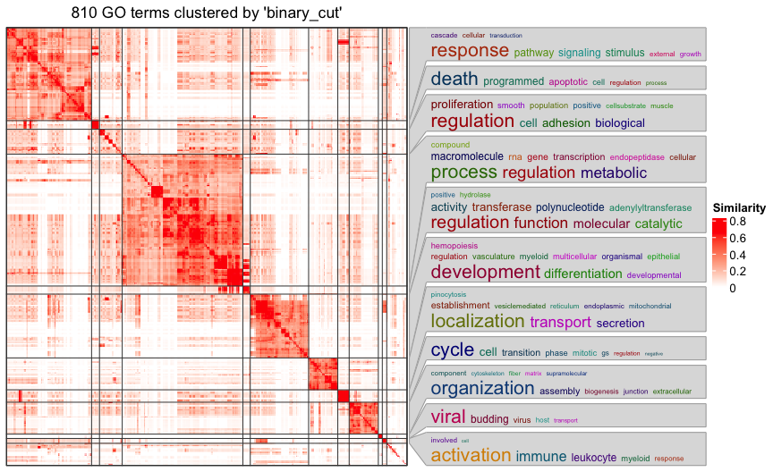

```r
simplifyGO(sig_go)
```